# Housing Prices

Author

Caio Sain Vallio

To renderin pdf: quarto install tool tinytex On termninal tinytex::install_tinytex() On console

## 1 Introduction

In this analysis, we build a model predicting sale prices of houses based on data on houses that were sold in the Duke Forest neighborhood of Durham, NC around November 2020. Let’s start by loading the packages we’ll use for the analysis.

**Packages**

```r
library(openintro)  # for data
library(tidyverse)  # for data wrangling and visualization
library(knitr)      # for tables
library(broom)      # for model summary
```

We present the results of exploratory data analysis in Section 2 and the regression model in Section 3.

## 2 Exploratory data analysis

The data contains 98 houses. As part of the exploratory analysis let’s visualize and summarize the relationship between areas and prices of these houses.

### 2.1 Data visualization

Figure 1 shows two histograms displaying the distributions of `price` and `area` individually.

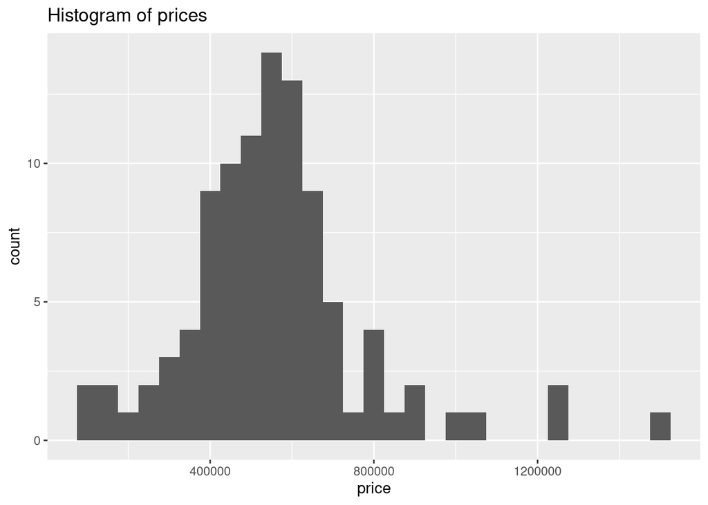

(a) Histogram of `price`s

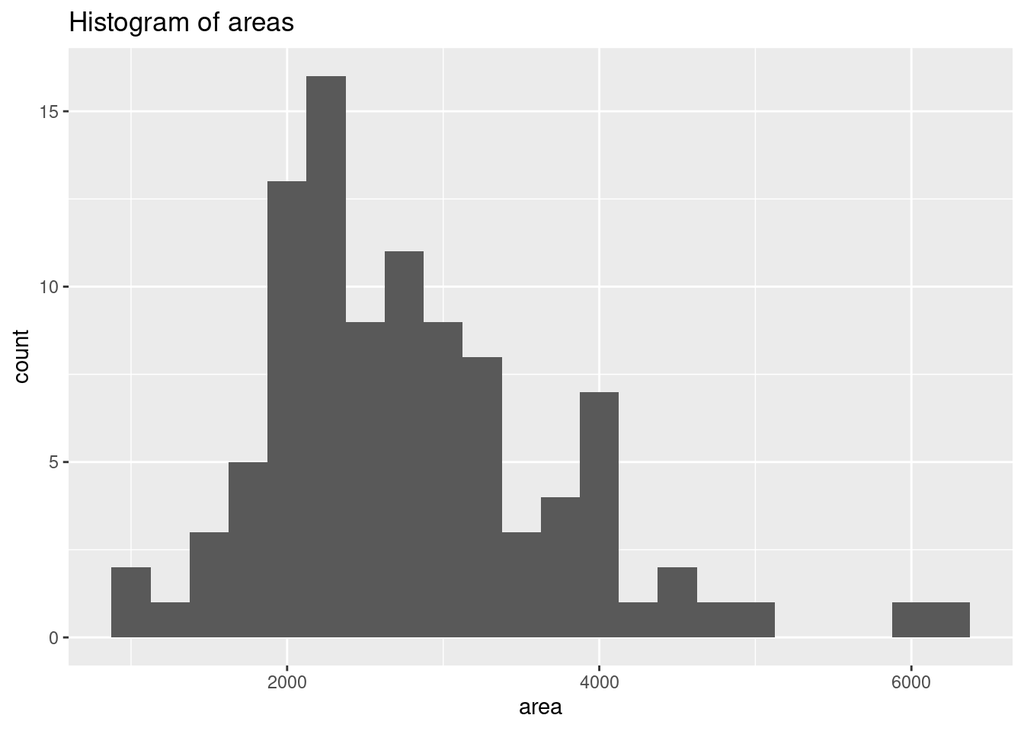

(b) Histogram of `area`s

Figure 1: Histograms of individual variables

```r
ggplot(duke_forest, aes(x = price)) +
  geom_histogram(binwidth = 50000) +
  labs(title = "Histogram of prices")

ggplot(duke_forest, aes(x = area)) +
  geom_histogram(binwidth = 250) +
  labs(title = "Histogram of areas")
```

Figure 2 displays the relationship between these two variables in a scatterplot.

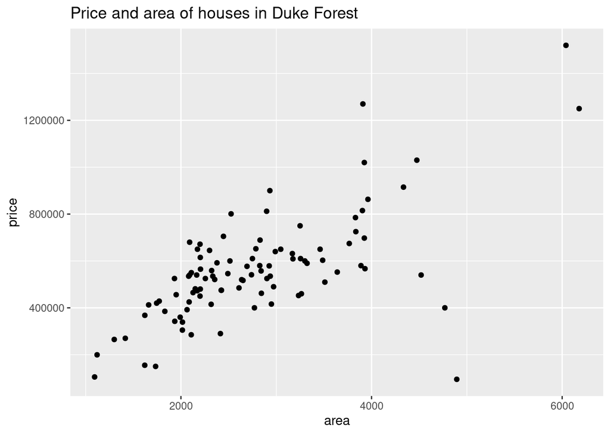

Figure 2: Scatterplot of price vs. area of houses in Duke Forest

```r
ggplot(duke_forest, aes(x = area, y = price)) +
  geom_point() +
  labs(title = "Price and area of houses in Duke Forest")
```

### 2.2 Summary statistics

Table 1 displays basic summary statistics for these two variables.

```r
duke_forest %>%
  summarise(
    `Median price` = median(price),
    `IQR price` = IQR(price),
    `Median area` = median(area),
    `IQR area` = IQR(area),
    `Correlation, r` = cor(price, area)
    ) %>%
  kable(digits = c(0, 0, 0, 0, 2))
```

Table 1: Summary statistics for price and area of houses in Duke Forest

| Median price | IQR price | Median area | IQR area | Correlation, r |
| --- | --- | --- | --- | --- |
| 540000 | 193125 | 2623 | 1121 | 0.67 |

## 3 Modeling

Vou inserir uma citação aqui (Hespanhol et al. 2019). Assim como outra referência aqui (Lopes et al. 2012). Mais uma outra aqui (Hespanhol et al. 2021)

We can fit a simple linear regression model of the form shown in Equation 1.

$$price = \hat{\beta}_0 + \hat{\beta}_1 \times area + \epsilon
\tag{1}$$

Table 2 shows the regression output for this model.

```r
price_fit <- lm(price ~ area, data = duke_forest)

price_fit %>%
  tidy() %>%
  kable(digits = c(0, 0, 2, 2, 2))
```

Table 2: Linear regression model for predicting price from area

| term | estimate | std.error | statistic | p.value |
| --- | --- | --- | --- | --- |
| (Intercept) | 116652 | 53302.46 | 2.19 | 0.03 |
| area | 159 | 18.17 | 8.78 | 0.00 |

## 4 Modos de usar cross-ref

section Section 3  
Figure Figure 1  
Table Table 2  
Equation Equation 1

This is a pretty incomplete analysis, but hopefully the document provides a good overview of some of the authoring features of Quarto!

**Dicas maneiras**

This is a pretty incomplete analysis, but hopefully the document provides a good overview of some of the authoring features of Quarto!

This is a pretty incomplete analysis, but hopefully the document provides a good overview of some of the authoring features of Quarto!

**Important**

This is a pretty incomplete analysis, but hopefully the document provides a good overview of some of the authoring features of Quarto!

**Danger**

This is a pretty incomplete analysis, but hopefully the document provides a good overview of some of the authoring features of Quarto!

**Warning**

This is a pretty incomplete analysis, but hopefully the document provides a good overview of some of the authoring features of Quarto!

## References

Hespanhol, Luiz, Caio Sain Vallio, Lucíola Menezes Costa, and Bruno T Saragiotto. 2019. “Understanding and Interpreting Confidence and Credible Intervals Around Effect Estimates.” *Brazilian Journal of Physical Therapy* 23 (4): 290–301. https://doi.org/10.1016/j.bjpt.2018.12.006.

Hespanhol, Luiz, Caio Sain Vallio, Willem van Mechelen, and Evert Verhagen. 2021. “Can We Explain Running-Related Injury Preventive Behavior? A Path Analysis.” *Brazilian Journal of Physical Therapy* 25 (5): 601–9. https://doi.org/10.1016/j.bjpt.2021.04.007.

Lopes, Alexandre Dias, Luiz Carlos Hespanhol, Simon S Yeung, and Leonardo Oliveira Pena Costa. 2012. “What Are the Main Running-Related Musculoskeletal Injuries?” *Sports Medicine* 42 (10): 891–905.